ENGG1003 Project

# Analysis on Global Trade Volume and Macroeconomic Indicators

Author: Peter Raozen

Professor: Dr. Cheong Chi Hong

Submission: 06 December 2022

## Abstract

Today, countries all over the world are reliant on international trade. Just a century ago, people would consider this absurd: why would any country want to rely so heavily on other countries? What would happen to national security? Why would *the whole world*, then, even consider to do just that?

This notebook analyzes just that. It dives into some general statistics, trends, and correlations of international trade volume of countries worldwide to macroeconomic indicators such as the Human Development Index (HDI), Inequality, GDP per capita, and more based on publicly-available data from the World Bank and the United Nations.

Further observations are included after most visualizations to point out key characteristics of the world today in trade.

#### How to use

(Programming knowledge is ideal but not strictly necessary)

1. Make sure both files `data.xlsx` and `project.ipynb` are in the same folder.
2. On Jupyter Notebook, click on Cell > Run All.
3. Read this notebook like an article (be careful to not modify anything).
4. Enjoy!
- Setup
- Importing and Cleaning
  - NAs
- Analysis
  - World
  - Region
    - Trade Volume per Capita
  - Countries
    - Trade Volume per Capita
    - Income Groups
    - IHDI
    - Arable Land
- Conclusion
- Sidenotes
- Sources

## Setup

First, install the necessary packages. This step is optional if all packages are already installed.

**Ensure all packages are successfully installed and imported before proceeding with the rest of the notebook.**

```python
%pip -q install pandas openpyxl matplotlib seaborn
```

And then import them.

```python
import pandas as pd
import numpy as np
import matplotlib.pyplot as plt
import seaborn as sb

from matplotlib.ticker import PercentFormatter, FuncFormatter

import warnings
warnings.filterwarnings('ignore')
```

# Importing and Cleaning

**It is recommended to not have `data.xlsx` open in Microsoft Excel or other programs to prevent a `PermissionError`.**

Feel free to browse `data.xlsx` in Microsoft Excel or other programs **after** importing.

The dataset used in this analysis comes from multiple datasets from the World Bank and the UN (see Sources). They have been summarized into two comprehensive tables in the "Country Data" and "Region Data" sheets in `data.xlsx`. Data cleaning was also done in Excel, but the original datasets remain in separate sheets (perhaps with slight modifications for data merging).

> **Note:** `data.xlsx` has conditional formatting that this notebook does not require. The following code blocks that import data from it may report a warning regarding it or an "unknown extension." They can be ignored as all other codeblocks will run normally despite so.

Start with importing Country Data:

```python
countryDf = pd.read_excel('./data.xlsx', sheet_name='Country Data')
print(f'Shape: {countryDf.shape}')
countryDf.describe()
```

```
Shape: (235, 19)
```

|  | Exports (US$ Thousands) | Imports (US$ Thousands) | Export Share (%) | Import Share (%) | Export per capita (US$) | Import per capita (US$) | Population | GDP Per Capita (US$) | Country Growth (%) | IHDI | HDI-IHDI Loss (%) | Gini Coefficient | Arable Land (%) | Net Export (% of Export) |
| --- | --- | --- | --- | --- | --- | --- | --- | --- | --- | --- | --- | --- | --- | --- |
| count | 2.350000e+02 | 2.350000e+02 | 2.350000e+02 | 235.000000 | 204.000000 | 204.000000 | 2.040000e+02 | 202.000000 | 235.000000 | 152.000000 | 152.000000 | 153.000000 | 204.000000 | 235.000000 |
| mean | 7.323716e+07 | 8.168272e+07 | 4.252757e-01 | 0.424595 | 4491.417867 | 10152.662239 | 3.733424e+07 | 15051.433849 | -2.895574 | 0.598289 | 18.673359 | 37.318954 | 13.361470 | -349.257001 |
| std | 2.374373e+08 | 2.550343e+08 | 1.378758e+00 | 1.325693 | 7587.751641 | 33447.498024 | 1.431166e+08 | 20961.422976 | 5.360720 | 0.189736 | 9.872989 | 7.785114 | 13.479681 | 970.986379 |
| min | 3.670000e+00 | 0.000000e+00 | 2.131106e-08 | 0.000000 | 0.096064 | 1.772042 | 1.083400e+04 | 0.000000 | -23.180000 | 0.240000 | 4.357298 | 23.200000 | 0.000000 | -10747.335782 |
| 25% | 2.469063e+05 | 1.285561e+06 | 1.433743e-03 | 0.006682 | 253.721879 | 627.906681 | 1.117124e+06 | 1780.272868 | -5.305000 | 0.430500 | 10.304371 | 31.800000 | 2.842120 | -274.375908 |
| 50% | 4.070916e+06 | 7.743913e+06 | 2.363911e-02 | 0.040254 | 1172.552039 | 2410.087733 | 7.033272e+06 | 5322.179515 | -0.420000 | 0.600500 | 17.124084 | 35.900000 | 10.146441 | -57.656108 |
| 75% | 3.223731e+07 | 4.141831e+07 | 1.871965e-01 | 0.215296 | 5351.387474 | 8619.627553 | 2.642017e+07 | 19953.566771 | 0.000000 | 0.767000 | 26.809880 | 41.900000 | 19.009171 | 3.265750 |
| max | 2.681373e+09 | 2.697987e+09 | 1.557027e+01 | 14.024396 | 42685.454826 | 350910.792497 | 1.411100e+09 | 116356.158037 | 19.690000 | 0.915000 | 44.444444 | 63.000000 | 61.458093 | 100.000000 |

```python
regionDf = pd.read_excel('./data.xlsx', sheet_name='Region Data')
print(f'Shape: {regionDf.shape}')
regionDf.head(10)
```

```
Shape: (7, 15)
```

|  | ISO3 | Region | Countries | Exports (US$ Thousands) | Imports (US$ Thousands) | Net Export (% of Export) | Export Share (%) | Import Share (%) | Export per capita (US$) | Import per capita (US$) | Population | GDP Per Capita (US$) | IHDI | HDI-IHDI Loss (%) | Gini Coefficient |
| --- | --- | --- | --- | --- | --- | --- | --- | --- | --- | --- | --- | --- | --- | --- | --- |
| 0 | EAS | East Asia & Pacific | 36 | 5.921006e+09 | 5.269649e+09 | 0.110008 | 34.382270 | 27.392144 | 2507.288583 | 2231.466923 | 2361517682 | NaN | 0.630 | 15.887850 | — |
| 1 | ECS | Europe & Central Asia | 51 | 6.403842e+09 | 7.161591e+09 | -0.118327 | 37.186015 | 37.226642 | 6938.254005 | 7759.237940 | 922976036 | NaN | 0.714 | 10.301508 | — |
| 2 | LCN | Latin America & Caribbean | 38 | 1.029387e+09 | 9.741111e+08 | 0.053698 | 5.977476 | 5.063524 | 1577.930992 | 1493.198867 | 652365260 | NaN | 0.601 | 20.291777 | — |
| 3 | MEA | Middle East & North Africa | 20 | 7.322996e+08 | 9.687805e+08 | -0.322929 | 4.252338 | 5.035815 | 1576.389185 | 2085.451240 | 464542370 | NaN | 0.601 | 20.291777 | — |
| 4 | NAC | North America | 3 | 1.777090e+09 | 3.143796e+09 | -0.769070 | 10.319256 | 16.341758 | 4808.115041 | 8505.892563 | 369602177 | NaN | 0.601 | 20.291777 | — |
| 5 | SAS | South Asia | 8 | 3.334209e+08 | 4.632319e+08 | -0.389331 | 1.936118 | 2.407924 | 179.559511 | 249.467527 | 1856882402 | NaN | 0.476 | 24.683544 | — |
| 6 | SSF | Sub-Saharan Africa | 48 | 3.178978e+08 | 3.817942e+08 | -0.200997 | 1.845978 | 1.984603 | 279.828122 | 336.072624 | 1136046775 | NaN | 0.383 | 29.981718 | — |

### N/As

```python
countryDf.isna().sum()
```

```
ISO Code                     0
Name                         0
Region                      32
Exports (US$ Thousands)      0
Imports (US$ Thousands)      0
Export Share (%)             0
Import Share (%)             0
Export per capita (US$)     31
Import per capita (US$)     31
Population                  31
GDP Per Capita (US$)        33
Country Growth (%)           0
IHDI                        83
HDI-IHDI Loss (%)           83
Gini Coefficient            82
Arable Land (%)             31
Net Export (% of Export)     0
Uses Euro                    0
Income Group                 1
dtype: int64
```

**Region**

```python
countryDf[countryDf['Region'].isna()].sample(10).copy().reset_index()
```

|  | index | ISO Code | Name | Region | Exports (US$ Thousands) | Imports (US$ Thousands) | Export Share (%) | Import Share (%) | Export per capita (US$) | Import per capita (US$) | Population | GDP Per Capita (US$) | Country Growth (%) | IHDI | HDI-IHDI Loss (%) | Gini Coefficient | Arable Land (%) | Net Export (% of Export) | Uses Euro | Income Group |
| --- | --- | --- | --- | --- | --- | --- | --- | --- | --- | --- | --- | --- | --- | --- | --- | --- | --- | --- | --- | --- |
| 0 | 54 | CXR | Christmas Island | NaN | 1.560029e+04 | 2.459481e+04 | 9.058821e-05 | 0.000128 | NaN | NaN | NaN | NaN | 0.00 | NaN | NaN | NaN | NaN | -57.656108 | No | Others |
| 1 | 223 | VAT | Holy See | NaN | 1.379675e+04 | 8.566127e+04 | 8.011537e-05 | 0.000445 | NaN | NaN | NaN | NaN | 0.00 | NaN | NaN | NaN | NaN | -520.880062 | No | Others |
| 2 | 16 | BAT | Br. Antr. Terr | NaN | 3.670000e+00 | 0.000000e+00 | 2.131106e-08 | 0.000000 | NaN | NaN | NaN | NaN | 0.00 | NaN | NaN | NaN | NaN | 100.000000 | No | Others |
| 3 | 158 | OAS | Other Asia, nes | NaN | 5.194308e+08 | 2.879645e+08 | 3.016246e+00 | 1.496867 | NaN | NaN | NaN | NaN | 0.00 | NaN | NaN | NaN | NaN | 44.561532 | No | Others |
| 4 | 27 | BLM | Saint Barthélemy | NaN | 3.292620e+03 | 5.137948e+04 | 1.911968e-05 | 0.000267 | NaN | NaN | NaN | NaN | 0.00 | NaN | NaN | NaN | NaN | -1460.443659 | No | NaN |
| 5 | 156 | NRU | Nauru | NaN | 1.122825e+05 | 1.176534e+05 | 6.520050e-04 | 0.000612 | 10363.896991 | 10859.641868 | 10834.0 | 10580.268188 | 0.00 | NaN | NaN | 34.8 | 0.0 | -4.783383 | No | Others |
| 6 | 180 | SER | Serbia, FR(Serbia/Montenegro) | NaN | 1.989352e+07 | 4.248965e+07 | 1.155183e-01 | 0.220865 | NaN | NaN | NaN | NaN | -0.94 | NaN | NaN | NaN | NaN | -113.585413 | No | Others |
| 7 | 20 | BES | Bonaire | NaN | 7.734670e+03 | 3.886751e+05 | 4.491390e-05 | 0.002020 | NaN | NaN | NaN | NaN | 0.00 | NaN | NaN | NaN | NaN | -4925.102299 | No | Others |
| 8 | 142 | MSR | Montserrat | NaN | 5.811510e+03 | 2.058012e+04 | 3.374644e-05 | 0.000107 | NaN | NaN | NaN | NaN | -2.97 | NaN | NaN | NaN | NaN | -254.126896 | No | Others |
| 9 | 3 | AIA | Anguila | NaN | 3.358013e+04 | 1.549415e+05 | 1.949941e-04 | 0.000805 | NaN | NaN | NaN | NaN | 0.00 | NaN | NaN | NaN | NaN | -361.408249 | No | Others |

As you can see, the countries that do not have assigned regions are mostly island micro-nations or overseas territories with small enough populations that following analyses can let the NaNs here remain.

This theme continues with all other NaNs. Hence, their entries shall remain to preserve the data on the other columns. Yet, should that NaN datapoint be required, the whole entry will be disregarded.

**Some Others**

```python
countryDf[countryDf['IHDI'].isna() & countryDf['Arable Land (%)'].isna()].sample(10).copy().reset_index()
```

|  | index | ISO Code | Name | Region | Exports (US$ Thousands) | Imports (US$ Thousands) | Export Share (%) | Import Share (%) | Export per capita (US$) | Import per capita (US$) | Population | GDP Per Capita (US$) | Country Growth (%) | IHDI | HDI-IHDI Loss (%) | Gini Coefficient | Arable Land (%) | Net Export (% of Export) | Uses Euro | Income Group |
| --- | --- | --- | --- | --- | --- | --- | --- | --- | --- | --- | --- | --- | --- | --- | --- | --- | --- | --- | --- | --- |
| 0 | 162 | PCN | Pitcairn | NaN | 3.159910e+03 | 3.464480e+03 | 0.000018 | 0.000018 | NaN | NaN | NaN | NaN | 0.0 | NaN | NaN | NaN | NaN | -9.638566 | No | Others |
| 1 | 99 | IOT | British Indian Ocean Ter. | NaN | 1.365333e+04 | 4.520231e+04 | 0.000079 | 0.000235 | NaN | NaN | NaN | NaN | 0.0 | NaN | NaN | NaN | NaN | -231.071687 | No | Others |
| 2 | 207 | TKL | Tokelau | NaN | 4.215083e+04 | 1.384829e+04 | 0.000245 | 0.000072 | NaN | NaN | NaN | NaN | 0.0 | NaN | NaN | NaN | NaN | 67.145866 | No | Others |
| 3 | 10 | ATA | Antarctica | NaN | 1.010988e+04 | 4.828058e+04 | 0.000059 | 0.000251 | NaN | NaN | NaN | NaN | 0.0 | NaN | NaN | NaN | NaN | -377.558388 | No | Others |
| 4 | 223 | VAT | Holy See | NaN | 1.379675e+04 | 8.566127e+04 | 0.000080 | 0.000445 | NaN | NaN | NaN | NaN | 0.0 | NaN | NaN | NaN | NaN | -520.880062 | No | Others |
| 5 | 158 | OAS | Other Asia, nes | NaN | 5.194308e+08 | 2.879645e+08 | 3.016246 | 1.496867 | NaN | NaN | NaN | NaN | 0.0 | NaN | NaN | NaN | NaN | 44.561532 | No | Others |
| 6 | 27 | BLM | Saint Barthélemy | NaN | 3.292620e+03 | 5.137948e+04 | 0.000019 | 0.000267 | NaN | NaN | NaN | NaN | 0.0 | NaN | NaN | NaN | NaN | -1460.443659 | No | NaN |
| 7 | 54 | CXR | Christmas Island | NaN | 1.560029e+04 | 2.459481e+04 | 0.000091 | 0.000128 | NaN | NaN | NaN | NaN | 0.0 | NaN | NaN | NaN | NaN | -57.656108 | No | Others |
| 8 | 3 | AIA | Anguila | NaN | 3.358013e+04 | 1.549415e+05 | 0.000195 | 0.000805 | NaN | NaN | NaN | NaN | 0.0 | NaN | NaN | NaN | NaN | -361.408249 | No | Others |
| 9 | 182 | SGS | South Georgia and the South Sa | NaN | 3.901800e+02 | 7.633100e+02 | 0.000002 | 0.000004 | NaN | NaN | NaN | NaN | 0.0 | NaN | NaN | NaN | NaN | -95.630222 | No | Others |

## Analysis

### World

Let's do a quick overview of the entire world's trade volume.

```python
tradeDf = pd.read_excel('./data.xlsx', sheet_name='Trade Volume')
worldTrade = tradeDf[tradeDf['Partner ISO3'] == 'WLD']
totalImport = worldTrade['Import (US$ Thousand)'].sum()
totalExport = worldTrade['Export (US$ Thousand)'].sum()
print(f'Global Net Export (% of Export): {(1 - totalImport / totalExport) * 100:.2f}%')
print(f'Global Net Export US$ (Thousands): {totalExport - totalImport:,.0f}')
```

```
Global Net Export (% of Export): -11.71%
Global Net Export US$ (Thousands): -2,016,706,597
```

Ok, somehow we are importing more than we export. Are we getting these extra imports from aliens?

Haha. THe data itself contains miscellaneous "countries" such as "unspecified" and so forth. Hence, perhaps the extra imports come from unreported sources, either it be legal or illegal. Alternatively, perhaps trade is not as zero-sum as it might be, and the world might be generating that extra $2.0 trillion just from positive-sum transactions!

### Region

Have a look at how these regions compare to one another:

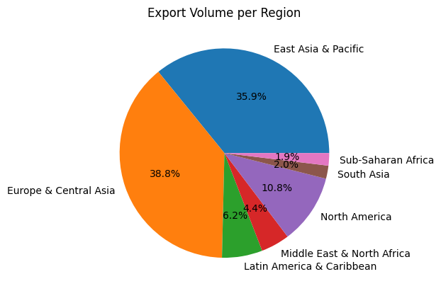

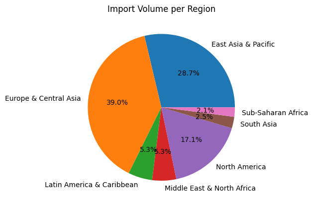

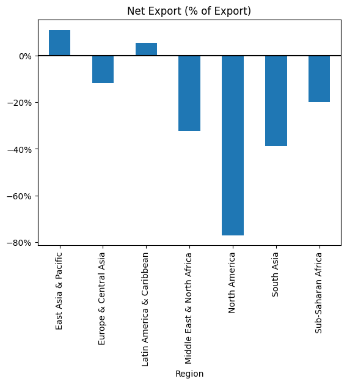

```python
regionDf.plot.pie(y='Exports (US$ Thousands)', labels=regionDf['Region'], autopct='%1.1f%%', ylabel='', title='Export Volume per Region', legend=False)
regionDf.plot.pie(y='Imports (US$ Thousands)', labels=regionDf['Region'], autopct='%1.1f%%', ylabel='', title='Import Volume per Region', legend=False)
ax = regionDf.plot.bar(x='Region', y='Net Export (% of Export)', legend=False, title='Net Export (% of Export)')
ax.yaxis.set_major_formatter(PercentFormatter(1.0))
plt.axhline(y=0, c='k')
```

It appears that the `Europe & Central Asia` and the `East Asia & Pacific` region makes up the largest portion of global trade volume, obvious, given her humongous population:

```python
pop = regionDf[regionDf['Region'].isin(['Europe & Central Asia', 'East Asia & Pacific'])][['Region', 'Population']]
totalPop = regionDf['Population'].sum()
pop.insert(2, '% Population', pop['Population'].div(totalPop))
pop
```

|  | Region | Population | % Population |
| --- | --- | --- | --- |
| 0 | East Asia & Pacific | 2361517682 | 0.304165 |
| 1 | Europe & Central Asia | 922976036 | 0.118880 |

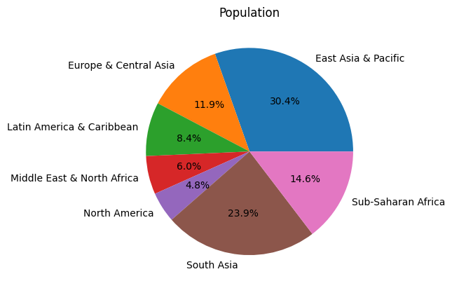

```python
regionDf.plot.pie(y='Population', labels=regionDf['Region'], autopct='%1.1f%%', ylabel='', title='Population', legend=False)
```

3.28 billion people. 42.2% of all humans on earth.

#### Trade Volume per Capita (Region)

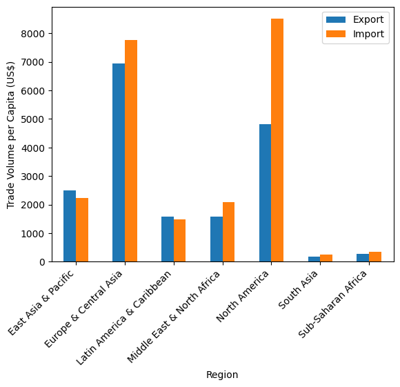

```python
regionDf.plot.bar(x='Region', y=['Export per capita (US$)', 'Import per capita (US$)'])
plt.xticks(rotation=45, ha='right')
plt.ylabel('Trade Volume per Capita (US$)')
plt.legend(['Export', 'Import'])
```

> *Follow up question: How much does manufacturing increase the value of imported goods once exported? How does this compare between countries?*

### Countries

What about countries?

```python
countryDf.describe()
```

|  | Exports (US$ Thousands) | Imports (US$ Thousands) | Export Share (%) | Import Share (%) | Export per capita (US$) | Import per capita (US$) | Population | GDP Per Capita (US$) | Country Growth (%) | IHDI | HDI-IHDI Loss (%) | Gini Coefficient | Arable Land (%) | Net Export (% of Export) |
| --- | --- | --- | --- | --- | --- | --- | --- | --- | --- | --- | --- | --- | --- | --- |
| count | 2.350000e+02 | 2.350000e+02 | 2.350000e+02 | 235.000000 | 204.000000 | 204.000000 | 2.040000e+02 | 202.000000 | 235.000000 | 152.000000 | 152.000000 | 153.000000 | 204.000000 | 235.000000 |
| mean | 7.323716e+07 | 8.168272e+07 | 4.252757e-01 | 0.424595 | 4491.417867 | 10152.662239 | 3.733424e+07 | 15051.433849 | -2.895574 | 0.598289 | 18.673359 | 37.318954 | 13.361470 | -349.257001 |
| std | 2.374373e+08 | 2.550343e+08 | 1.378758e+00 | 1.325693 | 7587.751641 | 33447.498024 | 1.431166e+08 | 20961.422976 | 5.360720 | 0.189736 | 9.872989 | 7.785114 | 13.479681 | 970.986379 |
| min | 3.670000e+00 | 0.000000e+00 | 2.131106e-08 | 0.000000 | 0.096064 | 1.772042 | 1.083400e+04 | 0.000000 | -23.180000 | 0.240000 | 4.357298 | 23.200000 | 0.000000 | -10747.335782 |
| 25% | 2.469063e+05 | 1.285561e+06 | 1.433743e-03 | 0.006682 | 253.721879 | 627.906681 | 1.117124e+06 | 1780.272868 | -5.305000 | 0.430500 | 10.304371 | 31.800000 | 2.842120 | -274.375908 |
| 50% | 4.070916e+06 | 7.743913e+06 | 2.363911e-02 | 0.040254 | 1172.552039 | 2410.087733 | 7.033272e+06 | 5322.179515 | -0.420000 | 0.600500 | 17.124084 | 35.900000 | 10.146441 | -57.656108 |
| 75% | 3.223731e+07 | 4.141831e+07 | 1.871965e-01 | 0.215296 | 5351.387474 | 8619.627553 | 2.642017e+07 | 19953.566771 | 0.000000 | 0.767000 | 26.809880 | 41.900000 | 19.009171 | 3.265750 |
| max | 2.681373e+09 | 2.697987e+09 | 1.557027e+01 | 14.024396 | 42685.454826 | 350910.792497 | 1.411100e+09 | 116356.158037 | 19.690000 | 0.915000 | 44.444444 | 63.000000 | 61.458093 | 100.000000 |

#### First Observations

```python
countryDf.sort_values('Net Export (% of Export)').head(5)
```

|  | ISO Code | Name | Region | Exports (US$ Thousands) | Imports (US$ Thousands) | Export Share (%) | Import Share (%) | Export per capita (US$) | Import per capita (US$) | Population | GDP Per Capita (US$) | Country Growth (%) | IHDI | HDI-IHDI Loss (%) | Gini Coefficient | Arable Land (%) | Net Export (% of Export) | Uses Euro | Income Group |
| --- | --- | --- | --- | --- | --- | --- | --- | --- | --- | --- | --- | --- | --- | --- | --- | --- | --- | --- | --- |
| 218 | UMI | United States Minor Outlying I | NaN | 14393.53 | 1561314.53 | 0.000084 | 0.008116 | NaN | NaN | NaN | NaN | 0.0 | NaN | NaN | NaN | NaN | -10747.335782 | No | Others |
| 81 | GIB | Gibraltar | NaN | 218246.64 | 11822535.51 | 0.001267 | 0.061455 | 6477.891425 | 350910.792497 | 33691.0 | 0.000000 | 0.0 | NaN | NaN | NaN | 0.000000 | -5317.052702 | No | Others |
| 20 | BES | Bonaire | NaN | 7734.67 | 388675.08 | 0.000045 | 0.002020 | NaN | NaN | NaN | NaN | 0.0 | NaN | NaN | NaN | NaN | -4925.102299 | No | Others |
| 229 | WLF | Wallis and Futura Isl. | NaN | 1726.39 | 59944.58 | 0.000010 | 0.000312 | NaN | NaN | NaN | NaN | 0.0 | NaN | NaN | NaN | NaN | -3372.250187 | No | Others |
| 202 | TCA | Turks and Caicos Isl. | Latin America & Caribbean | 9885.80 | 314629.31 | 0.000057 | 0.001635 | 255.328271 | 8126.176714 | 38718.0 | 29553.136698 | 0.0 | NaN | NaN | NaN | 1.052632 | -3082.638836 | No | High income |

Well it appears that a lot of countries do import a staggering amount. Although, they all mostly seem to be island micro-nations, which makes these figures somewhat more reasonable.

( Observations continued: )

```python
countryDf[countryDf['Name'] == 'Iceland']
```

|  | ISO Code | Name | Region | Exports (US$ Thousands) | Imports (US$ Thousands) | Export Share (%) | Import Share (%) | Export per capita (US$) | Import per capita (US$) | Population | GDP Per Capita (US$) | Country Growth (%) | IHDI | HDI-IHDI Loss (%) | Gini Coefficient | Arable Land (%) | Net Export (% of Export) | Uses Euro | Income Group |
| --- | --- | --- | --- | --- | --- | --- | --- | --- | --- | --- | --- | --- | --- | --- | --- | --- | --- | --- | --- |
| 103 | ISL | Iceland | Europe & Central Asia | 4404611.91 | 7996078.34 | 0.025577 | 0.041564 | 12019.254086 | 21819.606181 | 366463.0 | 59264.034091 | -6.95 | 0.915 | 4.588113 | 26.1 | 1.20004 | -81.538771 | No | High income |

#### Big Players

Let us have a look at the world's largest trading partners now:

```
(0.0, 2832886113.6765)
```

[figure not shown]

```python
from matplotlib.ticker import FuncFormatter

# String format thousands to trillions
def numFmt(x, pos):
    return '{:.0f}'.format(x / 1e9)

formatter = FuncFormatter(numFmt)

fig, ax = plt.subplots()

topDf = countryDf.sort_values('Exports (US$ Thousands)', ascending=False).head(10)

topDf.plot.bar(rot=0, x="Name", y=["Exports (US$ Thousands)", "Imports (US$ Thousands)"], ax=ax)
ax.legend(['Export', 'Import'])
ax.yaxis.set_major_formatter(numFmt)

plt.xticks(rotation=45, ha='right', fontsize='small')
plt.xlabel('')
plt.ylabel('Trade Volume (US$ Trillion)')
plt.ylim(bottom=0) # start y axis from 0
```

Have a look at that! According to this data, China is the largest exporter, and the US is the largest importer. No wonder many people really concerns a US-China trade war. Surprisingly, Germany is third! No wonder France historically always worries about a Germany that is too powerful.

```python
countryDf[countryDf['Name'].isin(['China', 'United States', 'Germany'])]
```

|  | ISO Code | Name | Region | Exports (US$ Thousands) | Imports (US$ Thousands) | Export Share (%) | Import Share (%) | Export per capita (US$) | Import per capita (US$) | Population | GDP Per Capita (US$) | Country Growth (%) | IHDI | HDI-IHDI Loss (%) | Gini Coefficient | Arable Land (%) | Net Export (% of Export) | Uses Euro | Income Group |
| --- | --- | --- | --- | --- | --- | --- | --- | --- | --- | --- | --- | --- | --- | --- | --- | --- | --- | --- | --- |
| 43 | CHN | China | East Asia & Pacific | 2.681373e+09 | 1.936140e+09 | 15.570273 | 10.064241 | 1900.200428 | 1372.078234 | 1.411100e+09 | 10408.669756 | -0.23 | 0.651 | 15.234375 | 38.2 | 12.676591 | 27.792973 | No | Upper middle income |
| 58 | DEU | Germany | Europe & Central Asia | 1.288732e+09 | 1.089247e+09 | 7.483447 | 5.662012 | 15496.858040 | 13098.073024 | 8.316087e+07 | 46252.689304 | -2.73 | 0.883 | 6.263270 | 31.7 | 33.383898 | 15.479170 | Yes | High income |
| 221 | USA | United States | North America | 1.381333e+09 | 2.697987e+09 | 8.021164 | 14.024396 | 4166.903159 | 8138.696788 | 3.315011e+08 | 63027.679527 | -3.21 | 0.819 | 11.074919 | 41.5 | 17.243857 | -95.317637 | No | High income |

```python
countryDf[['Name', 'Export per capita (US$)', 'Import per capita (US$)']].describe()
```

|  | Export per capita (US$) | Import per capita (US$) |
| --- | --- | --- |
| count | 204.000000 | 204.000000 |
| mean | 4491.417867 | 10152.662239 |
| std | 7587.751641 | 33447.498024 |
| min | 0.096064 | 1.772042 |
| 25% | 253.721879 | 627.906681 |
| 50% | 1172.552039 | 2410.087733 |
| 75% | 5351.387474 | 8619.627553 |
| max | 42685.454826 | 350910.792497 |

#### Trade Volume per Capita (Countries)

```
(0.0, 106422.12913877054)
```

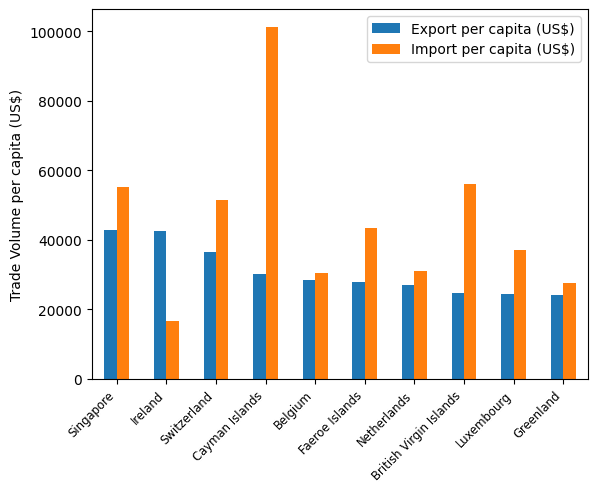

```python
topDf = countryDf.sort_values('Export per capita (US$)', ascending=False).head(10)
topDf.plot.bar(rot=0, x="Name", y=["Export per capita (US$)", "Import per capita (US$)"])
ax.legend(['Export', 'Import'])

plt.xticks(rotation=45, ha='right', fontsize='small')
plt.xlabel('')
plt.ylabel('Trade Volume per capita (US$)')
plt.ylim(bottom=0) # start y axis from 0
```

```
(0.0, 368456.33212133806)
```

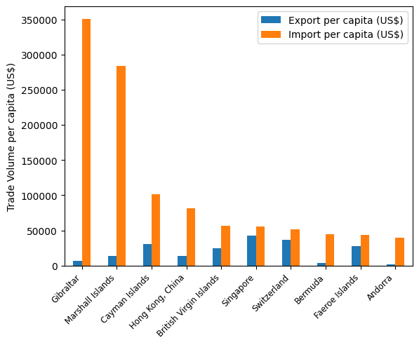

```python
topDf = countryDf.sort_values('Import per capita (US$)', ascending=False).head(10)
topDf.plot.bar(rot=0, x="Name", y=["Export per capita (US$)", "Import per capita (US$)"])
ax.legend(['Export', 'Import'])

plt.xticks(rotation=45, ha='right', fontsize='small')
plt.xlabel('')
plt.ylabel('Trade Volume per capita (US$)')
plt.ylim(bottom=0) # start y axis from 0
```

As expected, small territories with few natural resources import more than what they export. But some of these figures are downright mind-numbing. Gibraltar imports US$350,000 per citizen, followed closely by the Marshall Islands at $280,000. Hong Kong imports about US$80,000 per person. These amounts are enough to build a house in most parts of the world, and yet these places import that much per person in just 2020.

Interestingly, Singapore appears in both top tens. Hence, it seems to generate remarkably large trade volumes despite the small population, perhaps due to it being a highly strategic sea port.

#### Income Groups

```python
order = ['Low income', 'Lower middle income', 'Upper middle income', 'High income']

def violinPlot(field):
    incomeDf = countryDf[countryDf[field]> 0]
    ax = sb.violinplot(x=incomeDf['Income Group'], y=incomeDf[field], order=order)
    ax.set_yscale('log')
    plt.xticks(fontsize='small')
```

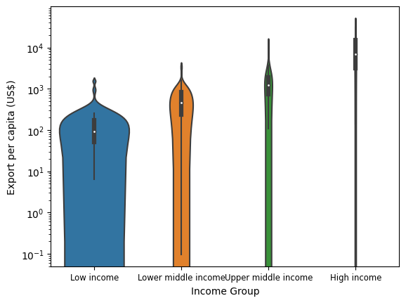

```python
violinPlot('Export per capita (US$)')
```

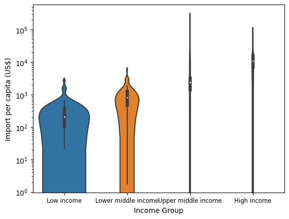

```python
violinPlot('Import per capita (US$)')
```

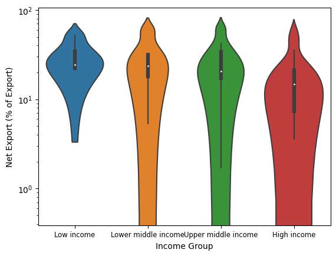

```python
violinPlot('Net Export (% of Export)')
```

#### IHDI

stands for Inequality-adjusted Human Development Index, a measure of the wellbeing of a country's citizens compensated for inequality

```python
colorDict = {
    'High income': 'b',
    'Upper middle income': 'g',
    'Lower middle income': 'y',
    'Low income': 'r'
}

def incomeGroupColor(group):
    if (group in colorDict):
        return colorDict[group]
    else:
        return 'gray'

colors = countryDf['Income Group'].copy().apply(incomeGroupColor)
```

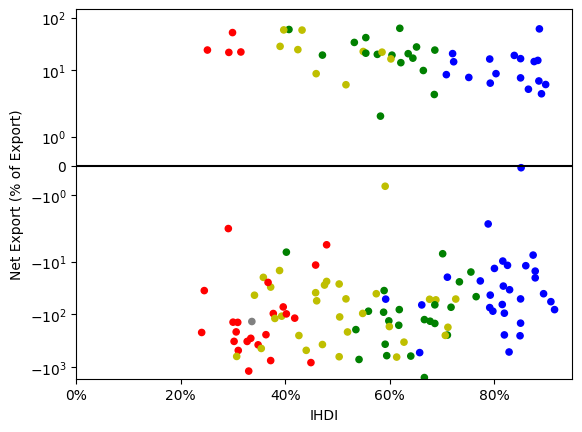

```python
ax = countryDf.plot.scatter(x='IHDI', y='Net Export (% of Export)', c=colors)
ax.xaxis.set_major_formatter(PercentFormatter(1.0))
ax.yaxis.set_major_formatter(PercentFormatter())
plt.axhline(y=0, color='k')
plt.xlim(left=0)

plt.yscale('symlog')
```

Okay. There are no strong correlations between Net Export and IHDI. Even within every income group, IHDI does not seem to have an effect on Net Exports altogether.

#### Arable land

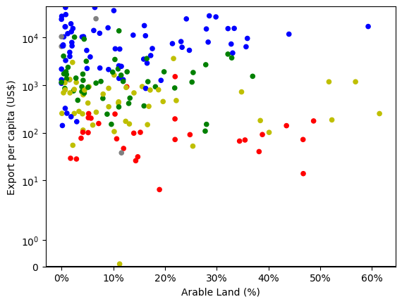

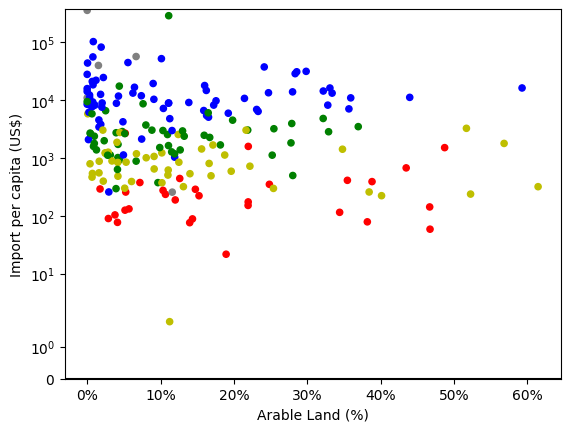

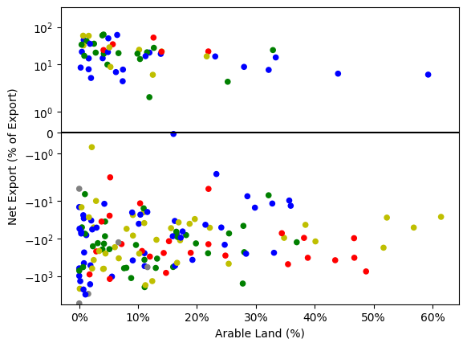

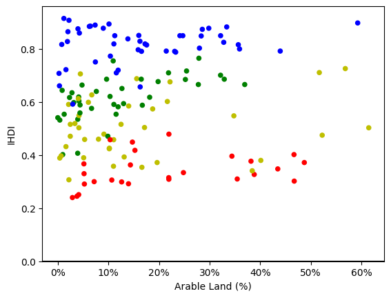

```python
fields = [
    ('Export per capita (US$)',  True, True),
    ('Import per capita (US$)',  True, True),
    ('Net Export (% of Export)', False,  True),
    ('IHDI', True, False),
]

for field, startFromZero, symlog in fields:
    ax = countryDf.plot.scatter(x='Arable Land (%)', y=field, c=colors)
    ax.xaxis.set_major_formatter(PercentFormatter(100))
    ax.axhline(y=0, c='k')

    if startFromZero:
        plt.ylim(bottom=0)
    if symlog:
        plt.yscale('symlog')
```

It appears that neither Exports, Imports, Net Imports, nor IHDI see a correlation due to Percentage of Arable Land. If this were back before the Industrial Age, perhaps they would have had unmistakable correlations. Still, nowadays, that is no longer the case.

A lot of countries import more than they export as well now, regardless of arable land.

## Conclusion

We live in a fascinating world.

## Sidenotes

<sup>[1]</sup> For brevity, the terms "countries" refer to both countries *and* territories, whether recognized or unrecognized, with or without sovereignty. All such designations found in this notebook and the associated `.xlsx` file are all sourced from the World Bank and do not necessarily reflect the opinion of the author nor any other individual mentioned in this Notebook apart from the World Bank.

Meanwhile, a "region" is a socio-geopolitical area encompassing multiple countries over a continent-scale.

## Sources

1. [WITS of the World Bank - Global Trade Volume](https://wits.worldbank.org/CountryProfile/en/Country/WLD/Year/2020/TradeFlow/EXPIMP/Partner/all/Product/Total)
2. [World Bank - World population by country/region](https://data.worldbank.org/indicator/SP.POP.TOTL)
3. [World Bank - GDP per Capita (current US$)](https://data.worldbank.org/indicator/NY.GDP.PCAP.CD)
4. [United Nations - IHDI (Inequality-adjusted Human Development Index)](https://hdr.undp.org/inequality-adjusted-human-development-index#/indicies/IHDI)